# NY Solar Resource Data

Emmanuel Messori

12/09/2021

The solar resource data is available on the US open data website. To retrieve it we need an access key, freely available on [demand](https://developer.nrel.gov/signup/).

In particolar we’ll work with these output fields:

- The Average Direct Normal Irradiance(`avg_dni`): Direct Normal Irradiance is the amount of solar radiation a surface receives per unit area.
- The Average Tilt at Latitude (`avg_lat_tilt`): Tilt at Latitude is the amount of radiation a surface receives per unit area that doesn’t arrive on a direct path from the sun.
- The Average Global Horizontal Irradiance(`avg_ghi`): Global Horizontal Irradiance is the total amount of shortwave radiation a surface horizontal to the ground receives from above.

## API connection

```r
api_key <-"di7U1kMqN1orvvSS2efbg8tmprjRPQU2bvPnd0bd"
```

The next step is to determine the URL and the parameters to query the API. More info on the official [documentation](https://developer.nrel.gov/docs/solar/solar-resource-v1/).

```r
url <- "https://developer.nrel.gov/api/solar/solar_resource/v1.json"

#NY latitude
lat <- 41
#NY longitutude
lon <- -75

params <- list(api_key = api_key, lat = lat, lon = lon)
```

## Retrieving the data

We will define a function to retrieve the information through the API:

```r
library(httr)

solar_data_api <- function(u = url, q = params) {

  response <- GET(u, query = q)

  print(status_code(response))

  print(http_type(response))

  if (http_error(response)) {
    print(http_status(response))
    stop("Something wrong", .call = FALSE)
  }

  if (http_type(response) != "application/json") {
stop("API did not return json", call. = FALSE)
}
  json_content <- content(response, "text")

  data <- jsonlite::fromJSON(json_content)

  data
}
```

Now we can retrieve the data :

```r
data <- solar_data_api()
```

```
## [1] 200
## [1] "application/json"
```

```r
str(data)
```

```
## List of 6
##  $ version : chr "1.0.0"
##  $ warnings: list()
##  $ errors  : list()
##  $ metadata:List of 1
##   ..$ sources: chr "Perez-SUNY/NREL, 2012"
##  $ inputs  :List of 2
##   ..$ lat: chr "41"
##   ..$ lon: chr "-75"
##  $ outputs :List of 3
##   ..$ avg_dni     :List of 2
##   .. ..$ annual : num 3.69
##   .. ..$ monthly:List of 12
##   .. .. ..$ jan: num 3.12
##   .. .. ..$ feb: num 3.36
##   .. .. ..$ mar: num 4.1
##   .. .. ..$ apr: num 4.07
##   .. .. ..$ may: num 4.15
##   .. .. ..$ jun: num 4.17
##   .. .. ..$ jul: num 4.6
##   .. .. ..$ aug: num 4.14
##   .. .. ..$ sep: num 4.02
##   .. .. ..$ oct: num 3.26
##   .. .. ..$ nov: num 2.58
##   .. .. ..$ dec: num 2.72
##   ..$ avg_ghi     :List of 2
##   .. ..$ annual : num 3.87
##   .. ..$ monthly:List of 12
##   .. .. ..$ jan: num 1.97
##   .. .. ..$ feb: num 2.69
##   .. .. ..$ mar: num 3.86
##   .. .. ..$ apr: num 4.7
##   .. .. ..$ may: num 5.45
##   .. .. ..$ jun: num 5.78
##   .. .. ..$ jul: num 5.98
##   .. .. ..$ aug: num 5.14
##   .. .. ..$ sep: num 4.23
##   .. .. ..$ oct: num 2.94
##   .. .. ..$ nov: num 1.99
##   .. .. ..$ dec: num 1.67
##   ..$ avg_lat_tilt:List of 2
##   .. ..$ annual : num 4.52
##   .. ..$ monthly:List of 12
##   .. .. ..$ jan: num 3.55
##   .. .. ..$ feb: num 4.04
##   .. .. ..$ mar: num 4.86
##   .. .. ..$ apr: num 4.97
##   .. .. ..$ may: num 5.18
##   .. .. ..$ jun: num 5.24
##   .. .. ..$ jul: num 5.58
##   .. .. ..$ aug: num 5.24
##   .. .. ..$ sep: num 5
##   .. .. ..$ oct: num 4.11
##   .. .. ..$ nov: num 3.26
##   .. .. ..$ dec: num 3.13
```

The resulting data is a nested list of lists. The 6 main lists contain information about the API, the call and the output.

## Processing the API response

We are interested in the information contained in the nested list `outputs`. This list contains in turn three lists of data:

```r
str(data$output)
```

```
## List of 3
##  $ avg_dni     :List of 2
##   ..$ annual : num 3.69
##   ..$ monthly:List of 12
##   .. ..$ jan: num 3.12
##   .. ..$ feb: num 3.36
##   .. ..$ mar: num 4.1
##   .. ..$ apr: num 4.07
##   .. ..$ may: num 4.15
##   .. ..$ jun: num 4.17
##   .. ..$ jul: num 4.6
##   .. ..$ aug: num 4.14
##   .. ..$ sep: num 4.02
##   .. ..$ oct: num 3.26
##   .. ..$ nov: num 2.58
##   .. ..$ dec: num 2.72
##  $ avg_ghi     :List of 2
##   ..$ annual : num 3.87
##   ..$ monthly:List of 12
##   .. ..$ jan: num 1.97
##   .. ..$ feb: num 2.69
##   .. ..$ mar: num 3.86
##   .. ..$ apr: num 4.7
##   .. ..$ may: num 5.45
##   .. ..$ jun: num 5.78
##   .. ..$ jul: num 5.98
##   .. ..$ aug: num 5.14
##   .. ..$ sep: num 4.23
##   .. ..$ oct: num 2.94
##   .. ..$ nov: num 1.99
##   .. ..$ dec: num 1.67
##  $ avg_lat_tilt:List of 2
##   ..$ annual : num 4.52
##   ..$ monthly:List of 12
##   .. ..$ jan: num 3.55
##   .. ..$ feb: num 4.04
##   .. ..$ mar: num 4.86
##   .. ..$ apr: num 4.97
##   .. ..$ may: num 5.18
##   .. ..$ jun: num 5.24
##   .. ..$ jul: num 5.58
##   .. ..$ aug: num 5.24
##   .. ..$ sep: num 5
##   .. ..$ oct: num 4.11
##   .. ..$ nov: num 3.26
##   .. ..$ dec: num 3.13
```

We will focus on the monthly values. Now we have to convert these lists into a dataframe.

```r
values <- data$outputs
avg_dni <- unlist(values$avg_dni$monthly)
avg_ghi <- unlist(values$avg_ghi$monthly)
avg_lat_tilt <- unlist(values$avg_lat_tilt$monthly)
month <- month.abb

ny_sd <- dplyr::bind_cols(month = month, avg_dni = avg_dni, avg_ghi = avg_ghi,
                 avg_lat_tilt = avg_lat_tilt)


ny_sd
```

```
## # A tibble: 12 x 4
##    month avg_dni avg_ghi avg_lat_tilt
##    <chr>   <dbl>   <dbl>        <dbl>
##  1 Jan      3.12    1.97         3.55
##  2 Feb      3.36    2.69         4.04
##  3 Mar      4.1     3.86         4.86
##  4 Apr      4.07    4.7          4.97
##  5 May      4.15    5.45         5.18
##  6 Jun      4.17    5.78         5.24
##  7 Jul      4.6     5.98         5.58
##  8 Aug      4.14    5.14         5.24
##  9 Sep      4.02    4.23         5
## 10 Oct      3.26    2.94         4.11
## 11 Nov      2.58    1.99         3.26
## 12 Dec      2.72    1.67         3.13
```

Another approach of treating the raw data consist of simplifying the complex list and restructuring it into the desired output :

```r
#1. Unlist the data
values <- unlist(values)

#2. Transform the resulting vector into a matrix of 13 rows (12 monthly values + 1 annual value)
mat <- matrix(values, nrow = 13)

#3. Convert the matrix into a dataframe
solar_data <- as.data.frame(mat)
colnames(solar_data) <- c("avg_dni", "avg_ghi", "avg_lat_tilt")

#4. Removing the annual values:
solar_data <- solar_data[-1,]
rownames(solar_data)<-NULL
```

## Visualising the data

```r
library(tidyverse)
```

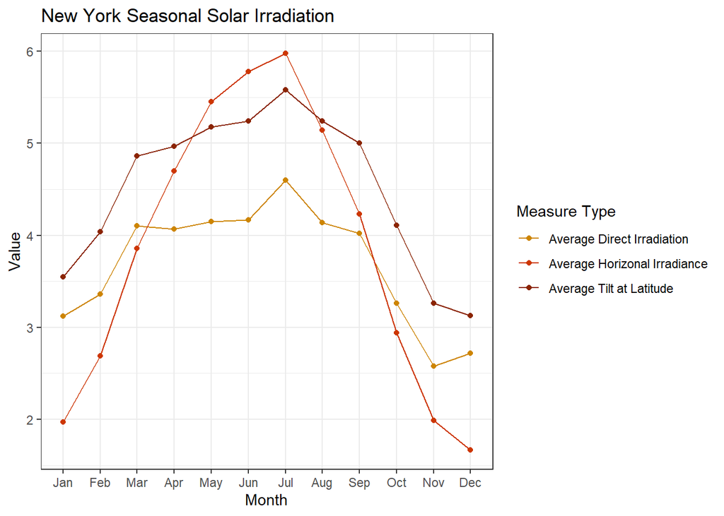

```r
theme_set(theme_bw())

ny_sd %>% pivot_longer(cols = 2:4, names_to = "measure") %>% ggplot(aes(factor(month, levels = month.abb), value, group= measure, color = measure)) + geom_line() + geom_point() + labs(title = "New York Seasonal Solar Irradiation", x="Month", y="Value") + scale_color_manual(name="Measure Type",labels=c("Average Direct Irradiation", "Average Horizonal Irradiance", "Average Tilt at Latitude"), values=c("orange3", "orangered3", "orangered4" ))
```